[figure not shown]

# Machine Learning Programming Workshop

## 2.3 Multi-Class Classification with Logistic Regression

#### Prepared By: [Cheong Shiu Hong (FTFNCE)](https://www.linkedin.com/in/cheongshiuhong/)

## Contents

- 1) Intuition Behind Multi-Class Logistic Regression
- 2) Multi-Class Logistic Regression with Iris Dataset
- 3) Multi-Class Logistic Regression with Sci-Kit Learn
- 4) Other Algorithms

```python
import numpy as np
import pandas as pd
import matplotlib.pyplot as plt
```

# 1) Intuition Behind Multi-Class Logistic Regression

return to top

### Instead of Classifying Cancer or No Cancer, what if we had Multiple Classes?

#### E.g. Classifying if a Sample is a Cat, Dog, Rat, or a Snake

## Recap - Linear Regression

[figure not shown]

## Recap - Binary Logistic Regression

[figure not shown]

## Multi-Class Logistic Regression

### In Multi-Class Logistic Regression, the Ouptut of the Model will be a Vector instead of a Scalar Value

#### Each Number in the Vector Represents the Probability of each Sample being in that Class

[figure not shown]

### In the above scenerio of 3 Classes, the Output of the Model will be a Vector of 3 Values:

$\left[ {\begin{array}{c} P(y_{1} = 1) \\ P(y_{2} = 1) \\ P(y_{3} = 1) \end{array} } \right] $

### To Output a Vector of 3 Values, We Need Three Seperate Calculations (Nodes) for Each Value

[figure not shown]

### Weight Matrix:

#### The Weight Matrix Needs to be a (3 x 4) Matrix, or Number of Outputs (n_C) by Number of Inputs (n_F). The Number of Rows is Number of Classes, and Number of Columns is Number of Features.

### Bias Matrix:

#### Our Bias Matrix Needs to be a (3, 1) Matrix, or Number of Outputs (n_C) by 1. The Number of Rows is Number of Classes, and Number of Columns is 1.

### Question: Can the Sample be a Dog, a Cat, a Rat, and a Snake all at the Same Time?

[figure not shown]

#### For Non-Inclusive (Exclusive) classes, We will use Softmax as our Activation Function instead of Sigmoid.

### What is Softmax?

#### Hardmax is taking the Maximum Value of an Array and Outputting the Maximum as '1', while the rest are '0'.

$Hardmax(\left[ {\begin{array}{c} 0.1 \\ 1.2 \\ 0.5 \end{array} } \right])$ = $\left[ {\begin{array}{c} 0 \\ 1 \\ 0 \end{array} } \right]$

#### Softmax on the other hand, takes a 'Softer' Approach of Spreading the Values out on a Scale similar to Sigmoid.

#### The Highest Value will be set to a Value Closer to 1, while the Other Lower Values will be set to a Lower Value.

#### The Sum of All Values in the Vector for a Single Sample will add up to '1' with the below Formula:

## $\sigma(z_{j}) = \frac{e^{z_{j}}}{\sum\limits^{C}_{i=1}e^{z_{i}}}$

## $\sigma(Z) = \left[ {\begin{array}{c} \frac{e^{z_{1}}}{e^{z_{1}} + e^{z_{2}} + e^{z_{3}}} \\ \frac{e^{z_{2}}}{e^{z_{1}} + e^{z_{2}} + e^{z_{3}}} \\ \frac{e^{z_{3}}}{e^{z_{1}} + e^{z_{2}} + e^{z_{3}}} \end{array} } \right]$

#### Note that the Same Input Value might not always Output the Same Value, as the Output is Dependent on the other Input Values.

### Define the Softmax Function

```python
def softmax(array):
    return np.exp(array) / np.sum(np.exp(array), -1, keepdims=True)
```

#### Visualize what Softmax Does to a 2-Class Dataset

```python
a = np.arange(50)/5
b = a[::-1]

c = np.vstack([a,b]).T

pd.DataFrame(c, columns=['Increasing', 'Decreasing'])
```

|  | Increasing | Decreasing |
| --- | --- | --- |
| 0 | 0.0 | 9.8 |
| 1 | 0.2 | 9.6 |
| 2 | 0.4 | 9.4 |
| 3 | 0.6 | 9.2 |
| 4 | 0.8 | 9.0 |
| 5 | 1.0 | 8.8 |
| 6 | 1.2 | 8.6 |
| 7 | 1.4 | 8.4 |
| 8 | 1.6 | 8.2 |
| 9 | 1.8 | 8.0 |
| 10 | 2.0 | 7.8 |
| 11 | 2.2 | 7.6 |
| 12 | 2.4 | 7.4 |
| 13 | 2.6 | 7.2 |
| 14 | 2.8 | 7.0 |
| 15 | 3.0 | 6.8 |
| 16 | 3.2 | 6.6 |
| 17 | 3.4 | 6.4 |
| 18 | 3.6 | 6.2 |
| 19 | 3.8 | 6.0 |
| 20 | 4.0 | 5.8 |
| 21 | 4.2 | 5.6 |
| 22 | 4.4 | 5.4 |
| 23 | 4.6 | 5.2 |
| 24 | 4.8 | 5.0 |
| 25 | 5.0 | 4.8 |
| 26 | 5.2 | 4.6 |
| 27 | 5.4 | 4.4 |
| 28 | 5.6 | 4.2 |
| 29 | 5.8 | 4.0 |
| 30 | 6.0 | 3.8 |
| 31 | 6.2 | 3.6 |
| 32 | 6.4 | 3.4 |
| 33 | 6.6 | 3.2 |
| 34 | 6.8 | 3.0 |
| 35 | 7.0 | 2.8 |
| 36 | 7.2 | 2.6 |
| 37 | 7.4 | 2.4 |
| 38 | 7.6 | 2.2 |
| 39 | 7.8 | 2.0 |
| 40 | 8.0 | 1.8 |
| 41 | 8.2 | 1.6 |
| 42 | 8.4 | 1.4 |
| 43 | 8.6 | 1.2 |
| 44 | 8.8 | 1.0 |
| 45 | 9.0 | 0.8 |
| 46 | 9.2 | 0.6 |
| 47 | 9.4 | 0.4 |
| 48 | 9.6 | 0.2 |
| 49 | 9.8 | 0.0 |

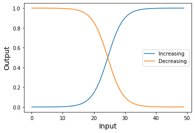

```python
plt.plot(softmax(c)[:,0], label='Increasing');
plt.plot(softmax(c)[:,1], label='Decreasing');
plt.xlabel('Input', fontsize=14), plt.ylabel('Output', fontsize=14)
plt.legend();
```

# 2) Multi-Class Logistic Regression with Iris Dataset

return to top

### Import Iris Dataset from Sci-Kit Learn Library

```python
import sklearn.datasets as datasets
import time # To Track Time
```

```python
iris = datasets.load_iris()
```

### Let's Check Out the Dataset

```python
iris.keys()
```

```
dict_keys(['data', 'target', 'target_names', 'DESCR', 'feature_names', 'filename'])
```

```python
print("Feature Names:\n", iris['feature_names'], "\n\nLabel Names:\n", iris['target_names'])
```

```
Feature Names:
 ['sepal length (cm)', 'sepal width (cm)', 'petal length (cm)', 'petal width (cm)']

Label Names:
 ['setosa' 'versicolor' 'virginica']
```

#### Define Num Features (n_F) and Num Classes(n_C)

```python
n_F = len(iris['feature_names'])
n_C = len(iris['target_names'])
```

#### Shape of X and Y

```python
iris['data'].shape, iris['target'].shape
```

```
((150, 4), (150,))
```

```python
df = pd.DataFrame(iris['data'], columns=iris['feature_names'])
df.head()
```

|  | sepal length (cm) | sepal width (cm) | petal length (cm) | petal width (cm) |
| --- | --- | --- | --- | --- |
| 0 | 5.1 | 3.5 | 1.4 | 0.2 |
| 1 | 4.9 | 3.0 | 1.4 | 0.2 |
| 2 | 4.7 | 3.2 | 1.3 | 0.2 |
| 3 | 4.6 | 3.1 | 1.5 | 0.2 |
| 4 | 5.0 | 3.6 | 1.4 | 0.2 |

```python
X = iris['data'].T
Y_class = iris['target']
```

```python
X.shape, Y_class.shape
```

```
((4, 150), (150,))
```

### One-Hot Encode Labels

```python
def one_hot(array, num_classes):
    new_array = np.zeros((len(array), num_classes))
    for i, val in enumerate(array):
        new_array[i, val] = 1
    return new_array
```

```python
Y = one_hot(Y_class, n_C).T
```

```python
Y.shape
```

```
(3, 150)
```

### Shuffle Data

```python
indices = np.arange(iris['target'].shape[0])
np.random.shuffle(indices)
```

```python
indices
```

```
array([  1,  70, 107, 149,  76,  75,  15,  67, 130,  74, 129,  93, 140,
        64,  44,  54,  27,   2, 101,  87,  43,   5,  39,  79, 120,  20,
        33,   6,   4,  69,  10, 102,  73,  34,  63, 116,  47,   7,  29,
        53, 106, 104,  94,  24, 121,  30, 112,  58, 131,  60, 132, 115,
       108, 136, 127,  59,  41, 143, 100, 119, 109,   9, 134, 148, 122,
        28,  55,  56, 144,  51,  19,  36,  95,  91,  88,  72, 142, 118,
        78,  99, 114,  89,   3, 126,  86,  83,  61,  46, 105,  81,  97,
       117,  57,  26,  80,  42,  92, 110, 133,  17,  90, 135, 111, 124,
       141, 145,  96,  71, 113,  49,  35,  45,  21,  32, 128,  68, 125,
        25,  37,  98, 147,   0, 137,  82,  66,  31,  62, 138, 123,  77,
        22,  18, 139,  48,  85,  50,  38,  23,  84,   8,  14,  13,  11,
       103, 146,  65,  16,  40,  12,  52])
```

```python
X = X[:,indices]
Y = Y[:,indices]
Y_class = Y_class[indices]
```

### Train Test Split

```python
split_ratio = 0.2
split = int(Y.shape[1] * split_ratio)

X_train = X[:, split:]
X_val = X[:, :split]
Y_train = Y[:, split:]
Y_val = Y[:, :split]
Y_class_train = Y_class[split:]
Y_class_val = Y_class[:split]
```

### Initialize Weights and Biases

#### Weights (C x F)

```python
weights = np.random.randn(n_C, n_F) # Num Classes x Num Features
```

```python
weights
```

```
array([[ 0.91057411, -1.73159604,  0.25916453,  0.65316311],
       [-0.19227925, -0.28523107, -0.78849773,  0.02460387],
       [-0.15662074, -0.57448763, -1.70533646, -0.71892338]])
```

#### Biases (C x 1)

```python
biases = np.zeros((n_C, 1))
```

```python
biases
```

```
array([[0.],
       [0.],
       [0.]])
```

### Define Model

```python
# Activation Function
def softmax(x):
    return np.exp(x)/sum(np.exp(x))
```

```python
# Model
def model(biases, weights, X):
    return softmax(biases + np.dot(weights, X))
```

#### Test the Model to Check the Shape of the Output - Expected: C x M

```python
model(biases, weights, X_train).shape
```

```
(3, 120)
```

### Define Cost Function

```python
def cost(prediction, Y, epsilon=1e-10):
    error = np.sum((Y * np.log(prediction + epsilon)) + ((1 - Y) * np.log(1 - prediction + epsilon)), -1)/Y.shape[1]
    return - np.sum(error)
```

### Define Training Algorithm

```python
def train(X, Y, biases, weights, epochs=1, learning_rate=1e-2, iterations=1):

    for epoch in range(epochs):
        start = time.time()
        for iteration in range(iterations):
            # Forward Pass
            pred = model(biases, weights, X)

            # Calculate Loss
            loss = cost(pred, Y)

            # Calculate Gradients
            db = np.sum((pred - Y), -1, keepdims=True) / Y.shape[1]
            dw = np.dot((pred - Y), X.T) / Y.shape[1]

            # Calculate Accuracy
            class_pred = np.argmax(pred, 0)
            class_y = np.argmax(Y, 0)
            acc = np.sum(class_pred == class_y)/Y.shape[1]

            # Update Biases and Weights
            biases -= (learning_rate * db)
            weights -= (learning_rate * dw)

        print('Epoch {}:'.format(epoch+1))
        print('Loss: {:.2f} | Accuracy: {:.2f}%\nTime Taken: {:.2f}s\n'.format(loss, acc*100, time.time()-start))

    return biases, weights
```

### Define Function for Predicting

```python
def predict(X, Y, biases, weights):
    # Forward Pass
    pred = model(biases, weights, X)

    # Calculate Accuracy
    class_pred = np.argmax(pred, 0)
    class_y = np.argmax(Y, 0)
    acc = np.sum(class_pred == class_y)/Y.shape[1]

    return acc, pred
```

### Training The Parameters for 20 x 100 Iterations

```python
biases, weights = train(X_train, Y_train, biases, weights, epochs=20, iterations=100)
```

```
Epoch 1:
Loss: 2.48 | Accuracy: 13.33%
Time Taken: 0.01s

Epoch 2:
Loss: 1.56 | Accuracy: 66.67%
Time Taken: 0.01s

Epoch 3:
Loss: 1.23 | Accuracy: 67.50%
Time Taken: 0.01s

Epoch 4:
Loss: 1.09 | Accuracy: 70.83%
Time Taken: 0.01s

Epoch 5:
Loss: 1.00 | Accuracy: 75.83%
Time Taken: 0.01s

Epoch 6:
Loss: 0.94 | Accuracy: 83.33%
Time Taken: 0.01s

Epoch 7:
Loss: 0.89 | Accuracy: 89.17%
Time Taken: 0.01s

Epoch 8:
Loss: 0.85 | Accuracy: 90.00%
Time Taken: 0.01s

Epoch 9:
Loss: 0.81 | Accuracy: 92.50%
Time Taken: 0.02s

Epoch 10:
Loss: 0.78 | Accuracy: 94.17%
Time Taken: 0.01s

```

[output cut: 24 more lines]

```
Epoch 17:
Loss: 0.63 | Accuracy: 96.67%
Time Taken: 0.02s

Epoch 18:
Loss: 0.61 | Accuracy: 96.67%
Time Taken: 0.01s

Epoch 19:
Loss: 0.60 | Accuracy: 96.67%
Time Taken: 0.01s

Epoch 20:
Loss: 0.58 | Accuracy: 96.67%
Time Taken: 0.01s
```

```python
acc, _ = predict(X_val, Y_val, biases, weights)

print('Accuracy of Prediction on Validation Data: {:.2f}%'.format(acc*100))
```

```
Accuracy of Prediction on Validation Data: 96.67%
```

# 3) Multi-Class Logistic Regression with Sci-Kit Learn

return to top

### Sci-Kit Learn is a Powerful Python Library that has Many Built-In Machine Learning Algorithms

#### Import Sklearn's Logistic Regression Object from sklearn.linear_model

```python
from sklearn.linear_model import LogisticRegression
```

#### Instantiate the Logistic Regression Object

```python
model = LogisticRegression(solver='liblinear', multi_class='ovr', verbose=1)
```

#### Fit Model to Data

```python
model.fit(X_train.T, Y_class_train)
```

```
[LibLinear]
```

```
LogisticRegression(C=1.0, class_weight=None, dual=False, fit_intercept=True,
          intercept_scaling=1, max_iter=100, multi_class='ovr',
          n_jobs=None, penalty='l2', random_state=None, solver='liblinear',
          tol=0.0001, verbose=1, warm_start=False)
```

#### Evaluate Score of Fitted Model

```python
# Training Set
model.score(X_train.T, Y_class_train)
```

```
0.9666666666666667
```

```python
# Validation Set
model.score(X_val.T, Y_class_val)
```

```
0.9333333333333333
```

#### Note: When passing Labels(Y) into Sci-kit Learn, one-hot encoding is not required

#### Evaluate Cross Entropy Loss of Fitted Model

```python
skpred_t = model.predict_proba(X_train.T)
skpred_v = model.predict_proba(X_val.T)
skpred = model.predict_proba(X.T)

epsilon = 1e-10

# Cross Entropy Loss
train_loss = - np.mean((Y_train.T * np.log(skpred_t + epsilon)) + ((1-Y_train.T) * np.log(1-skpred_t + epsilon)))
val_loss = - np.mean((Y_val.T * np.log(skpred_v + epsilon)) + ((1-Y_val.T) * np.log(1-skpred_v + epsilon)))
total_loss = - np.mean((Y.T * np.log(skpred + epsilon)) + ((1-Y.T) * np.log(1-skpred + epsilon)))

print('Train Set Loss: {:.4f}'.format(train_loss))
print('Validation Set Loss: {:.4f}'.format(val_loss))
print('Total Loss: {:.4f}'.format(total_loss))
```

```
Train Set Loss: 0.2199
Validation Set Loss: 0.1911
Total Loss: 0.2141
```

## What happens if we keep stacking layers?

[figure not shown]

# 4) Other Algorithms

return to top

### Sci-kit Learn Documentation

### Naive Bayes

```python
from sklearn.naive_bayes import GaussianNB
```

```python
NB = GaussianNB()
```

```python
NB.fit(X.T, Y_class)
```

```
GaussianNB(priors=None, var_smoothing=1e-09)
```

```python
NB.score(X.T, Y_class)
```

```
0.96
```

### Decision Trees

```python
from sklearn.tree import DecisionTreeClassifier
```

```python
dec_tree = DecisionTreeClassifier()
```

```python
dec_tree.fit(X.T, Y_class)
```

```
DecisionTreeClassifier(class_weight=None, criterion='gini', max_depth=None,
            max_features=None, max_leaf_nodes=None,
            min_impurity_decrease=0.0, min_impurity_split=None,
            min_samples_leaf=1, min_samples_split=2,
            min_weight_fraction_leaf=0.0, presort=False, random_state=None,
            splitter='best')
```

```python
dec_tree.score(X.T, Y_class)
```

```
1.0
```

### Support Vector Machines

```python
from sklearn.svm import SVC
```

```python
SVM1 = SVC(kernel='linear')
SVM2 = SVC()
```

```python
SVM1.fit(X.T, Y_class)
SVM2.fit(X.T, Y_class)
```

```
SVC(C=1.0, cache_size=200, class_weight=None, coef0=0.0,
  decision_function_shape='ovr', degree=3, gamma='auto_deprecated',
  kernel='rbf', max_iter=-1, probability=False, random_state=None,
  shrinking=True, tol=0.001, verbose=False)
```

```python
SVM1.score(X.T, Y_class), SVM2.score(X.T, Y_class)
```

```
(0.9933333333333333, 0.9866666666666667)
```

### Ensemble Algorithms

```python
from sklearn.ensemble import RandomForestClassifier
```

```python
RFC = RandomForestClassifier()
```

```python
RFC.fit(X.T, Y_class)
```

```
RandomForestClassifier(bootstrap=True, class_weight=None, criterion='gini',
            max_depth=None, max_features='auto', max_leaf_nodes=None,
            min_impurity_decrease=0.0, min_impurity_split=None,
            min_samples_leaf=1, min_samples_split=2,
            min_weight_fraction_leaf=0.0, n_estimators=10, n_jobs=None,
            oob_score=False, random_state=None, verbose=0,
            warm_start=False)
```

```python
RFC.score(X.T, Y_class)
```

```
1.0
```

```python
from sklearn.neural_network import MLPClassifier
```

```python
NN1 = MLPClassifier(max_iter=1000, hidden_layer_sizes=3)
NN2 = MLPClassifier(max_iter=1000, hidden_layer_sizes=100)
NN3 = MLPClassifier(max_iter=1000, hidden_layer_sizes=300)
```

```python
NN1.fit(X.T, Y_class)
NN1.score(X.T, Y_class)
```

```
0.6333333333333333
```

```python
NN2.fit(X.T, Y_class)
NN2.score(X.T, Y_class)
```

```
0.98
```

```python
NN3.fit(X.T, Y_class)
NN3.score(X.T, Y_class)
```

```
0.98
```

```python
NN4 = MLPClassifier(max_iter=1000, hidden_layer_sizes=(25,50,25))
```

```python
NN4.fit(X.T, Y_class)
NN4.score(X.T, Y_class)
```

```
0.98
```

Previous: Next:

Logistic Regression Exercise Implementation with Sci-Kit Learn